# [해설]1-5_지도학습_classfication_estimators_정리

## 실습에 주로 활용할 데이터 셋

sklearn.dataset 에서 제공해주는 다양한 샘플 데이터 활용  
[참고 : sklearn.datasets](https://scikit-learn.org/stable/modules/classes.html#module-sklearn.datasets)

### iris 데이터셋

꽃 종류 분류하기  
[iris 데이터셋](https://scikit-learn.org/stable/modules/generated/sklearn.datasets.load_iris.html#sklearn.datasets.load_iris)

```python
import pandas as pd
from sklearn.datasets import load_iris
```

```python
# iris 데이터셋 로드
iris = load_iris()
```

**iris feature 설명**

- `DESCR`: 데이터셋의 정보를 보여줍니다.
- `data`: feature data.
- `feature_names`: feature data의 컬럼 이름
- `target`: label data (수치형)
- `target_names`: label의 이름 (문자형)

```python
print(iris['DESCR'])
```

```
.. _iris_dataset:

Iris plants dataset
--------------------

**Data Set Characteristics:**

    :Number of Instances: 150 (50 in each of three classes)
    :Number of Attributes: 4 numeric, predictive attributes and the class
    :Attribute Information:
        - sepal length in cm
        - sepal width in cm
        - petal length in cm
        - petal width in cm
        - class:
                - Iris-Setosa
                - Iris-Versicolour
                - Iris-Virginica

    :Summary Statistics:

    ============== ==== ==== ======= ===== ====================
                    Min  Max   Mean    SD   Class Correlation
    ============== ==== ==== ======= ===== ====================
    sepal length:   4.3  7.9   5.84   0.83    0.7826
    sepal width:    2.0  4.4   3.05   0.43   -0.4194
    petal length:   1.0  6.9   3.76   1.76    0.9490  (high!)
    petal width:    0.1  2.5   1.20   0.76    0.9565  (high!)
    ============== ==== ==== ======= ===== ====================

    :Missing Attribute Values: None
    :Class Distribution: 33.3% for each of 3 classes.
    :Creator: R.A. Fisher
    :Donor: Michael Marshall (MARSHALL%PLU@io.arc.nasa.gov)
    :Date: July, 1988

The famous Iris database, first used by Sir R.A. Fisher. The dataset is taken
from Fisher's paper. Note that it's the same as in R, but not as in the UCI
Machine Learning Repository, which has two wrong data points.

```

[output cut: 8 more lines]

```

   - Fisher, R.A. "The use of multiple measurements in taxonomic problems"
     Annual Eugenics, 7, Part II, 179-188 (1936); also in "Contributions to
     Mathematical Statistics" (John Wiley, NY, 1950).
   - Duda, R.O., & Hart, P.E. (1973) Pattern Classification and Scene Analysis.
     (Q327.D83) John Wiley & Sons.  ISBN 0-471-22361-1.  See page 218.
   - Dasarathy, B.V. (1980) "Nosing Around the Neighborhood: A New System
     Structure and Classification Rule for Recognition in Partially Exposed
     Environments".  IEEE Transactions on Pattern Analysis and Machine
     Intelligence, Vol. PAMI-2, No. 1, 67-71.
   - Gates, G.W. (1972) "The Reduced Nearest Neighbor Rule".  IEEE Transactions
     on Information Theory, May 1972, 431-433.
   - See also: 1988 MLC Proceedings, 54-64.  Cheeseman et al"s AUTOCLASS II
     conceptual clustering system finds 3 classes in the data.
   - Many, many more ...
```

```python
data = iris['data']
data[-5:]
```

```
array([[6.7, 3. , 5.2, 2.3],
       [6.3, 2.5, 5. , 1.9],
       [6.5, 3. , 5.2, 2. ],
       [6.2, 3.4, 5.4, 2.3],
       [5.9, 3. , 5.1, 1.8]])
```

```python
feature_names = iris['feature_names']
feature_names
```

```
['sepal length (cm)',
 'sepal width (cm)',
 'petal length (cm)',
 'petal width (cm)']
```

- **petal**: 꽃잎
- **sepal**: 꽃 받침

```python
target = iris['target']
target[:5]
```

```
array([0, 0, 0, 0, 0])
```

```python
# 타겟 값의 레이블(이름)
iris['target_names']
```

```
array(['setosa', 'versicolor', 'virginica'], dtype='<U10')
```

### 데이터프레임 만들기

```python
# [문제]feature들로 구성된 데이터 프레임 만들기

df_iris = pd.DataFrame(data, columns=feature_names)
```

```python
df_iris.head()
```

|  | sepal length (cm) | sepal width (cm) | petal length (cm) | petal width (cm) |
| --- | --- | --- | --- | --- |
| 0 | 5.1 | 3.5 | 1.4 | 0.2 |
| 1 | 4.9 | 3.0 | 1.4 | 0.2 |
| 2 | 4.7 | 3.2 | 1.3 | 0.2 |
| 3 | 4.6 | 3.1 | 1.5 | 0.2 |
| 4 | 5.0 | 3.6 | 1.4 | 0.2 |

```python
# [문제]df_iris 데이터 프레임에 target 컬럼 추가하기
df_iris['target'] = target
```

```python
df_iris.head()
```

|  | sepal length (cm) | sepal width (cm) | petal length (cm) | petal width (cm) | target |
| --- | --- | --- | --- | --- | --- |
| 0 | 5.1 | 3.5 | 1.4 | 0.2 | 0 |
| 1 | 4.9 | 3.0 | 1.4 | 0.2 | 0 |
| 2 | 4.7 | 3.2 | 1.3 | 0.2 | 0 |
| 3 | 4.6 | 3.1 | 1.5 | 0.2 | 0 |
| 4 | 5.0 | 3.6 | 1.4 | 0.2 | 0 |

### 시각화

```python
import matplotlib.pyplot as plt
import seaborn as sns
```

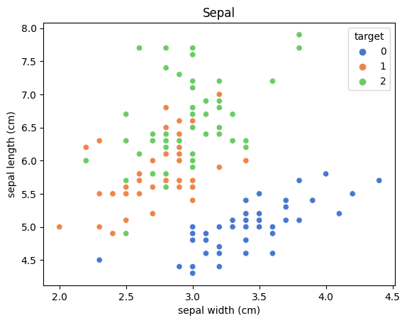

```python
# 꽃받침 정보에 따른 분류
#sns.scatterplot(data=df_iris, x='sepal width (cm)', y='sepal length (cm)', hue='target')
#sns.scatterplot(data=df_iris, x='sepal width (cm)', y='sepal length (cm)', hue='target', palette='brg')
sns.scatterplot(data=df_iris, x='sepal width (cm)', y='sepal length (cm)', hue='target', palette='muted')
plt.title('Sepal')
plt.show()
#'petal length (cm)', 'petal width (cm)',
```

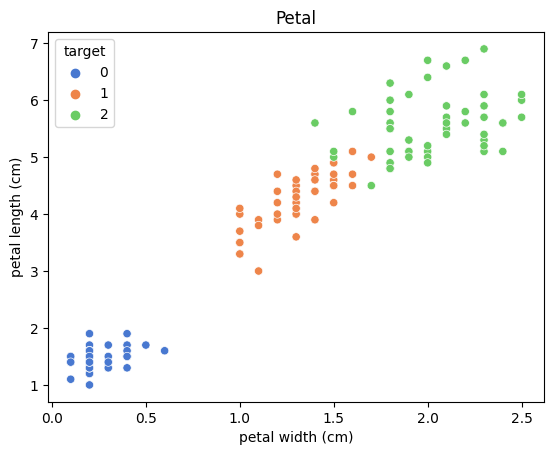

```python
# 꽃잎 정보에 따른 분류
sns.scatterplot(data=df_iris, x='petal width (cm)', y='petal length (cm)', hue='target', palette='muted')
plt.title('Petal')
plt.show()
```

### 데이터 불균형 확인

```python
from sklearn.model_selection import train_test_split
```

```python
X = df_iris.drop('target', axis=1)
```

```python
y = df_iris['target']
```

```python
X_train, X_test, y_train, y_test = train_test_split(X, y, test_size=0.25)
```

```python
X_train.shape, y_train.shape
```

```
((112, 4), (112,))
```

```python
X_test.shape, y_test.shape
```

```
((38, 4), (38,))
```

[figure not shown]

```python
sns.countplot(y_train)
```

```python
X_train, X_test, y_train, y_test = train_test_split(X, y, test_size=0.25, random_state=10, stratify=y)
```

```python
sns.countplot(y_train)
```

[output not shown]

[output cut: 25 more lines]

[output not shown]

```python
X_train.shape, y_train.shape
```

[output not shown]

```python
X_test.shape, y_test.shape
```

[output not shown]

```python
sns.get_dataset_names()
```

[output not shown]

# 지도학습 알고리즘 이해 및 실습

## 의사 결정 나무 (Decision Tree)

- 스무고개 처럼 질문에 True or False로 판별하여, 바이너리 트리 형태로 가지치기를 하여 결정함
- 데이터 균일도에 따른 규칙기반 결정으로 다음 노드 결정

### 장점

- 매우 쉽고, 유연함.
- 데이터 스케일링이나 정규화등의 사전 가공의 영향이 매우 적음.

### 단점

- depth가 깊어지면 과적합(overfitting)에 빠질 수 있음.

앙상블에서 결정트리의 단점을 보완하여 약한 학습기로 가중치를 계속 업데이터하면서 예측성능을 향상시킬 수 학습기로 사용함.  
[Decision Tree scikit-learning 문서 참조](https://scikit-learn.org/stable/modules/generated/sklearn.tree.DecisionTreeClassifier.html?highlight=decision%20tree#sklearn.tree.DecisionTreeClassifier)

[figure not shown]

```python
from sklearn.tree import DecisionTreeClassifier
```

```python
model_dtc = DecisionTreeClassifier(random_state=0)
model_dtc
```

```
DecisionTreeClassifier(random_state=0)
```

```python
model_dtc.fit(X_train, y_train)
```

```
DecisionTreeClassifier(random_state=0)
```

```python
y_pred = model_dtc.predict(X_test)
y_pred
```

```
array([1, 1, 2, 2, 2, 1, 0, 2, 2, 0, 1, 1, 2, 1, 0, 2, 0, 1, 0, 0, 2, 2,
       0, 1, 2, 0, 2, 2, 1, 2, 0, 0, 0, 1, 1, 1, 0, 2])
```

```python
(y_pred == y_test).mean()
```

```
0.9736842105263158
```

```python
y_pred[:5]
```

```
array([1, 1, 2, 2, 2])
```

```python
y_test[:5].values
```

```
array([1, 1, 2, 2, 2])
```

```python
from sklearn.metrics import classification_report
# Predict를 수행하고 classification_report() 결과 출력
y_pred = model_dtc.predict(X_test)
print(classification_report(y_test, y_pred))
```

```
              precision    recall  f1-score   support

           0       1.00      1.00      1.00        12
           1       1.00      0.92      0.96        13
           2       0.93      1.00      0.96        13

    accuracy                           0.97        38
   macro avg       0.98      0.97      0.97        38
weighted avg       0.98      0.97      0.97        38
```

### Decision Tree Graph display(결정트리 시각화)

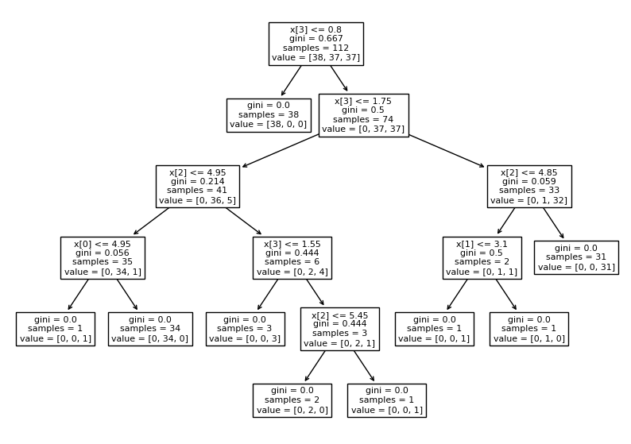

```python
import matplotlib.pyplot as plt
from sklearn.tree import plot_tree
plt.figure(figsize=(10, 7))
plot_tree(model_dtc)
plt.show()
```

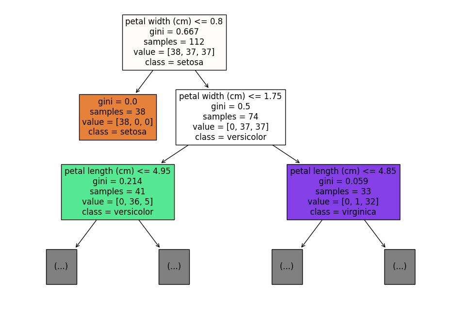

```python
plt.figure(figsize=(12,8))
plot_tree(model_dtc, max_depth=2, filled=True, feature_names=feature_names, class_names=iris['target_names'])
plt.show()
```

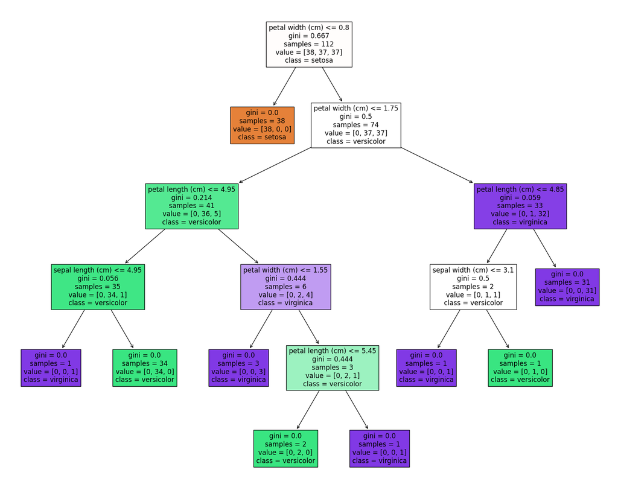

```python
plt.figure(figsize=(20,16))
plot_tree(model_dtc, filled=True, feature_names=feature_names, class_names=iris['target_names'])
plt.show()
```

gini계수: 불순도를 의미하며, 계수가 높을 수록 엔트로피가 큼.  
엔트로피가 크다는 의미는 클래스가 혼잡하게 섞여 있다는 뜻임.

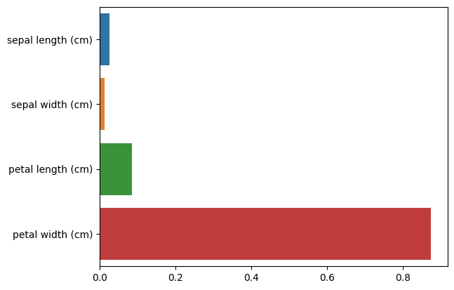

```python
sns.barplot(x=model_dtc.feature_importances_, y=iris.feature_names)
```

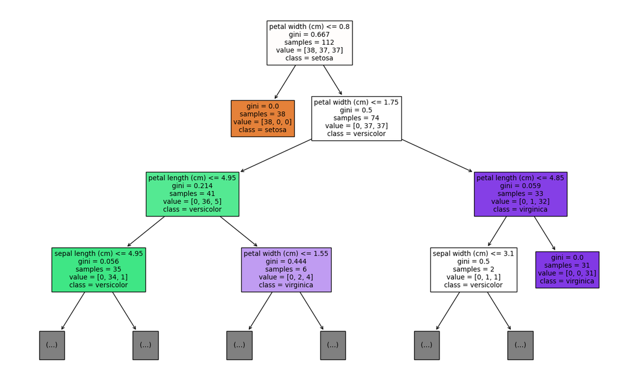

```python
# max_depth=3으로 설정
plt.figure(figsize=(16,10))
plot_tree(model_dtc, max_depth=3, filled=True, feature_names=feature_names, class_names=iris['target_names'])
plt.show()
```

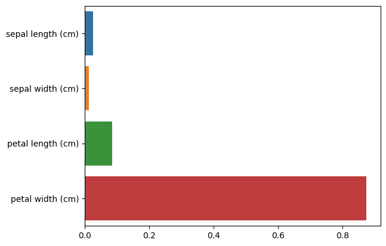

```python
sns.barplot(x=model_dtc.feature_importances_, y=iris.feature_names)
```

# [문제] decision tree로 다음의 하이퍼 파리메터를 설정하고 학습

- min_samples_split=4
- min_samples_leaf=4
- max_depth = ?

```python
# 모델 만들고, 테스트, 성능평가
model_dtc = DecisionTreeClassifier(random_state=0, min_samples_leaf=4)
model_dtc.fit(X_train, y_train)
y_pred = model_dtc.predict(X_test)
y_pred = model_dtc.predict(X_test)
print(classification_report(y_test, y_pred))
```

```
              precision    recall  f1-score   support

           0       1.00      1.00      1.00        12
           1       1.00      1.00      1.00        13
           2       1.00      1.00      1.00        13

    accuracy                           1.00        38
   macro avg       1.00      1.00      1.00        38
weighted avg       1.00      1.00      1.00        38
```

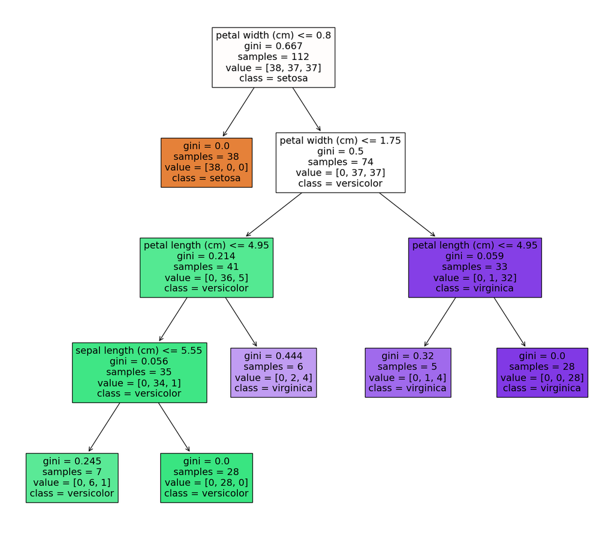

```python
# max_depth=3으로 설정
plt.figure(figsize=(16,14))
#plot_tree(model_dtc, max_depth=3, filled=True, feature_names=feature_names, class_names=iris['target_names'])
plot_tree(model_dtc, filled=True, feature_names=feature_names, class_names=iris['target_names'])
plt.show()
```

## Logistic Regression

[Logistic Regression scikit-learning 문서](https://scikit-learn.org/stable/modules/generated/sklearn.linear_model.LogisticRegression.html?highlight=logistic%20regression#sklearn.linear_model.LogisticRegression)

- 로지스틱 회귀(영어: logistic regression)는 영국의 통계학자인 D. R. Cox가 1958년에 제안한 확률 모델
- 독립 변수의 선형 결합을 이용하여 사건의 발생 가능성을 예측하는데 사용되는 통계 기법

[figure not shown]

- LogisticRegression, 서포트 벡터 머신 (SVM) 과 같은 알고리즘은 이진 분류만 가능. 즉, 2개의 클래스 판별만 가능함.
- 3개 이상의 클래스에 대한 판별을 진행하는 경우, 다음과 같은 전략으로 판별함.
  - **one-vs-rest (OvR)**: K 개의 클래스가 존재할 때, 1개의 클래스를 제외한 다른 클래스를 K개 만들어,  
    각각의 이진 분류에 대한 확률을 구하고, 총합을 통해 최종 클래스를 판별
  - **one-vs-one (OvO)**: 4개의 계절을 구분하는 클래스가 존재한다고 가정했을 때,  
    0vs1, 0vs2, 0vs3, ... , 2vs3 까지 NX(N-1)/2 개의 분류기를 만들어 가장 많이 양성으로 선택된 클래스를 판별
  - 일반적으로 **OvsR 전략을 선호** 함.

```python
from sklearn.linear_model import LogisticRegression
```

### step1 모델 선언

```python
model_lr = LogisticRegression(max_iter=500)
```

### step2 모델 학습

```python
model_lr.fit(X_train, y_train)
```

```
LogisticRegression(max_iter=500)
```

### step3 예측

```python
pred_lr = model_lr.predict(X_test)
```

```python
pred_lr[:5]
```

```
array([1, 1, 2, 2, 2])
```

```python
y_test[:5]
```

```
74     1
90     1
146    2
125    2
144    2
Name: target, dtype: int32
```